# DSC1107_MONFERO_SA1

### Bias-Variance Trade-Off

> Explain the concept of bias-variance trade-off in the context of the models trained.

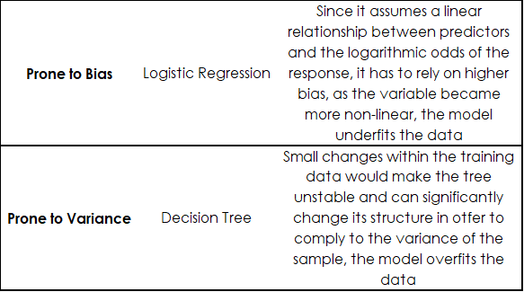

```r
# Display the image
include_graphics("Quack2.png")
```

> Discuss how model complexity affects performance.
- `Logistic regression` is ideal for understanding the impact of individual predictors (like `ContractOne Year`) on `Churn`. It provides clear coefficients and a probabilistic interpretation.
- `Decision trees` are more suited for capturing interactions among predictors and providing interpretable decision paths. However, they need tuning to prevent overfitting, especially when working with categorical predictors like `Contract`

### Cross-Validation

> Use k-fold cross-validation (k=10) to evaluate model performance.

```r
# Define the control for k-fold cross-validation
train_control <- trainControl(method = "cv", number = 10,
                               classProbs = TRUE,
                               summaryFunction = multiClassSummary)
```

```r
# Train logistic regression model with cross-validation
logistic_cv <- train(Churn ~ Tenure + MonthlyCharges + TotalCharges + InternetService + Contract,
                     data = train_data,
                     method = "glm",
                     family = "binomial",
                     trControl = train_control)
# View the results
logistic_cv
```

```
## Generalized Linear Model
##
## 6950 samples
##    5 predictor
##    2 classes: 'No', 'Yes'
##
## No pre-processing
## Resampling: Cross-Validated (10 fold)
## Summary of sample sizes: 6255, 6255, 6255, 6254, 6255, 6255, ...
## Resampling results:
##
##   logLoss    AUC        prAUC      Accuracy   Kappa  F1         Sensitivity
##   0.5849385  0.5036039  0.5044266  0.7289211  0      0.8432091  1
##   Specificity  Pos_Pred_Value  Neg_Pred_Value  Precision  Recall
##   0            0.7289211       NaN             0.7289211  1
##   Detection_Rate  Balanced_Accuracy
##   0.7289211       0.5
```

```r
# Train decision tree model with cross-validation
decision_tree_cv <- train(Churn ~ Tenure + MonthlyCharges + TotalCharges + InternetService + Contract,
                          data = train_data,
                          method = "rpart",
                          trControl = train_control)
# View the results
decision_tree_cv
```

```
## CART
##
## 6950 samples
##    5 predictor
##    2 classes: 'No', 'Yes'
##
## No pre-processing
## Resampling: Cross-Validated (10 fold)
## Summary of sample sizes: 6255, 6254, 6256, 6256, 6255, 6256, ...
## Resampling results across tuning parameters:
##
##   cp            logLoss    AUC        prAUC      Accuracy   Kappa
##   0.0003538570  0.8311488  0.4940050  0.4910062  0.6726653  -0.017343310
##   0.0003980892  0.7522388  0.4985165  0.4419796  0.6886402  -0.009925709
##   0.0004128332  0.7522388  0.4985165  0.4419796  0.6886402  -0.009925709
##   F1         Sensitivity  Specificity  Pos_Pred_Value  Neg_Pred_Value
##   0.7975059  0.8855053    0.10028707   0.7257415       0.2449281
##   0.8104473  0.9167010    0.07534898   0.7271674       0.2240309
##   0.8104473  0.9167010    0.07534898   0.7271674       0.2240309
##   Precision  Recall     Detection_Rate  Balanced_Accuracy
##   0.7257415  0.8855053  0.6454720       0.4928962
##   0.7271674  0.9167010  0.6682098       0.4960250
##   0.7271674  0.9167010  0.6682098       0.4960250
##
## Accuracy was used to select the optimal model using the largest value.
## The final value used for the model was cp = 0.0004128332.
```

> Report and interpret accuracy, precision, recall, and F1-score.

[figure not shown]

```r
include_graphics("Quack3.png")
```

### Classification

> Train a Random Forest classifier to predict customer churn.

```r
# Convert Churn variable to factor (if not already)
train_data$Churn <- factor(train_data$Churn)

# Handle missing values (example for TotalCharges)
train_data$TotalCharges[is.na(train_data$TotalCharges)] <- median(train_data$TotalCharges, na.rm = TRUE)
```

```r
# Train the Random Forest model
random_forest_model <- randomForest(Churn ~ Tenure + MonthlyCharges + TotalCharges + InternetService + Contract,
                                    data = train_data,
                                    ntree = 500,        # Number of trees
                                    mtry = 3,           # Number of predictors sampled at each split
                                    importance = TRUE,  # Enable feature importance
                                    proximity = TRUE)   # Enable proximity matrix
```

```r
# Summary of the model
print(random_forest_model)
```

```
##
## Call:
##  randomForest(formula = Churn ~ Tenure + MonthlyCharges + TotalCharges +      InternetService + Contract, data = train_data, ntree = 500,      mtry = 3, importance = TRUE, proximity = TRUE)
##                Type of random forest: classification
##                      Number of trees: 500
## No. of variables tried at each split: 3
##
##         OOB estimate of  error rate: 33.19%
## Confusion matrix:
##       No Yes class.error
## No  4466 600   0.1184366
## Yes 1707 177   0.9060510
```

```r
# Importance of predictors
importance(random_forest_model)
```

```
##                         No        Yes MeanDecreaseAccuracy MeanDecreaseGini
## Tenure          40.5927183 -43.966163            34.408608         440.8363
## MonthlyCharges  47.9941670 -44.267640            39.543477        1026.9583
## TotalCharges    40.8776465 -43.675620            35.009615         989.8966
## InternetService  9.9553072  -1.224511             7.851462         135.8814
## Contract        -0.8368726  -7.776821            -4.873507         136.1927
```

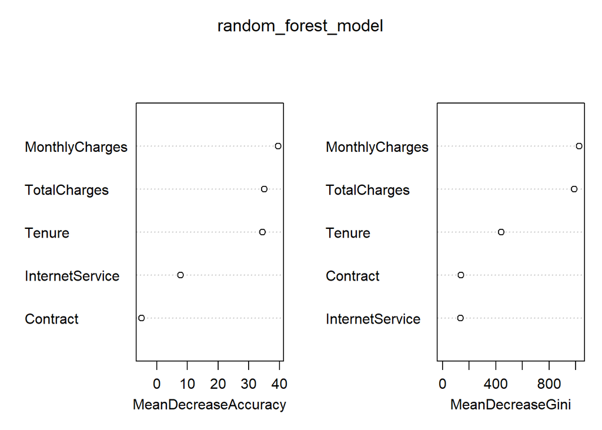

```r
varImpPlot(random_forest_model)
```

```r
# Generate predictions
rf_predictions <- predict(random_forest_model, test_data)

# Confusion matrix
confusion_matrix_rf <- confusionMatrix(rf_predictions, test_data$Churn)
print(confusion_matrix_rf)
```

```
## Confusion Matrix and Statistics
##
##           Reference
## Prediction   No  Yes
##        No  1920  713
##        Yes  251   94
##
##                Accuracy : 0.6763
##                  95% CI : (0.6592, 0.6931)
##     No Information Rate : 0.729
##     P-Value [Acc > NIR] : 1
##
##                   Kappa : 0.0011
##
##  Mcnemar's Test P-Value : <2e-16
##
##             Sensitivity : 0.8844
##             Specificity : 0.1165
##          Pos Pred Value : 0.7292
##          Neg Pred Value : 0.2725
##              Prevalence : 0.7290
##          Detection Rate : 0.6447
##    Detection Prevalence : 0.8842
##       Balanced Accuracy : 0.5004
##
##        'Positive' Class : No
##
```

```r
library(MLmetrics)

# Calculate performance metrics
Accuracy <- Accuracy(rf_predictions, test_data$Churn)
Precision <- Precision(rf_predictions, test_data$Churn, positive = "Yes")
Recall <- Recall(rf_predictions, test_data$Churn, positive = "Yes")
F1 <- F1_Score(rf_predictions, test_data$Churn, positive = "Yes")

# Print metrics
cat("Random Forest Metrics:\n")
```

```
## Random Forest Metrics:
```

```r
cat("Accuracy: ", Accuracy, "\n")
```

```
## Accuracy:  0.6762928
```

```r
cat("Precision: ", Precision, "\n")
```

```
## Precision:  0.1164808
```

```r
cat("Recall: ", Recall, "\n")
```

```
## Recall:  0.2724638
```

```r
cat("F1-Score: ", F1, "\n")
```

```
## F1-Score:  0.1631944
```

> Tune hyperparameters using grid search.

```r
# Correct tuning grid for Random Forest
tune_grid <- expand.grid(mtry = c(2, 3, 4))  # Number of predictors at each split
```

```r
train_control <- trainControl(method = "cv",
                               number = 5,
                               classProbs = TRUE,
                               summaryFunction = twoClassSummary)
```

```r
# Check for missing values
colSums(is.na(train_data))
```

```
##      CustomerID          Gender   SeniorCitizen         Partner      Dependents
##               0               0               0               0               0
##          Tenure    PhoneService InternetService        Contract  MonthlyCharges
##               0               0               0               0               0
##    TotalCharges           Churn
##               0               0
```

```r
# Impute missing values for numeric variables
train_data$TotalCharges[is.na(train_data$TotalCharges)] <- median(train_data$TotalCharges, na.rm = TRUE)
```

```r
# Perform grid search with the corrected tuning grid
rf_model <- train(Churn ~ Tenure + MonthlyCharges + TotalCharges + InternetService + Contract,
                  data = train_data,
                  method = "rf",
                  trControl = train_control,
                  tuneGrid = tune_grid,
                  ntree = 500)  # Specify number of trees
```

```r
# Confusion Matrix
confusion_matrix_rf <- confusionMatrix(rf_predictions, test_data$Churn)
print(confusion_matrix_rf)
```

```
## Confusion Matrix and Statistics
##
##           Reference
## Prediction   No  Yes
##        No  1920  713
##        Yes  251   94
##
##                Accuracy : 0.6763
##                  95% CI : (0.6592, 0.6931)
##     No Information Rate : 0.729
##     P-Value [Acc > NIR] : 1
##
##                   Kappa : 0.0011
##
##  Mcnemar's Test P-Value : <2e-16
##
##             Sensitivity : 0.8844
##             Specificity : 0.1165
##          Pos Pred Value : 0.7292
##          Neg Pred Value : 0.2725
##              Prevalence : 0.7290
##          Detection Rate : 0.6447
##    Detection Prevalence : 0.8842
##       Balanced Accuracy : 0.5004
##
##        'Positive' Class : No
##
```

```r
# Accuracy
Accuracy <- Accuracy(rf_predictions, test_data$Churn)

# Precision
Precision <- Precision(rf_predictions, test_data$Churn, positive = "Yes")

# Recall
Recall <- Recall(rf_predictions, test_data$Churn, positive = "Yes")

# F1-Score
F1 <- F1_Score(rf_predictions, test_data$Churn, positive = "Yes")

# Print final metrics
cat("Final Random Forest Model Performance:\n")
```

```
## Final Random Forest Model Performance:
```

```r
cat("Accuracy: ", Accuracy, "\n")
```

```
## Accuracy:  0.6762928
```

```r
cat("Precision: ", Precision, "\n")
```

```
## Precision:  0.1164808
```

```r
cat("Recall: ", Recall, "\n")
```

```
## Recall:  0.2724638
```

```r
cat("F1-Score: ", F1, "\n")
```

```
## F1-Score:  0.1631944
```